# Jahresabschluss mithilfe von NLP

Simon Valverde

21.5.2021

## Deskriptive

Der Jahresabschluss hat 181 Seiten und 67707 Wörter, von denen 46990 zur Analyse geeignet waren.

folgende Wöter wurden entfernt: aber, alle, allem, allen, aller, alles, als, also, am, an, ander, andere, anderem, anderen, anderer, anderes, anderm, andern, anderr, anders, auch, auf, aus, bei, bin, bis, bist, da, damit, dann, der, den, des, dem, die, das, daß, derselbe, derselben, denselben, desselben, demselben, dieselbe, dieselben, dasselbe, dazu, dein, deine, deinem, deinen, deiner, deines, denn, derer, dessen, dich, dir, du, dies, diese, diesem, diesen, dieser, dieses, doch, dort, durch, ein, eine, einem, einen, einer, eines, einig, einige, einigem, einigen, einiger, einiges, einmal, er, ihn, ihm, es, etwas, euer, eure, eurem, euren, eurer, eures, für, gegen, gewesen, hab, habe, haben, hat, hatte, hatten, hier, hin, hinter, ich, mich, mir, ihr, ihre, ihrem, ihren, ihrer, ihres, euch, im, in, indem, ins, ist, jede, jedem, jeden, jeder, jedes, jene, jenem, jenen, jener, jenes, jetzt, kann, kein, keine, keinem, keinen, keiner, keines, können, könnte, machen, man, manche, manchem, manchen, mancher, manches, mein, meine, meinem, meinen, meiner, meines, mit, muss, musste, nach, nicht, nichts, noch, nun, nur, ob, oder, ohne, sehr, sein, seine, seinem, seinen, seiner, seines, selbst, sich, sie, ihnen, sind, so, solche, solchem, solchen, solcher, solches, soll, sollte, sondern, sonst, über, um, und, uns, unse, unsem, unsen, unser, unses, unter, viel, vom, von, vor, während, war, waren, warst, was, weg, weil, weiter, welche, welchem, welchen, welcher, welches, wenn, werde, werden, wie, wieder, will, wir, wird, wirst, wo, wollen, wollte, würde, würden, zu, zum, zur, zwar, zwischen, , dass, a, c, s, 2, 1, 0

## Frequent Word analysis

Hier schauen wir uns häufig verwendete Wörter an

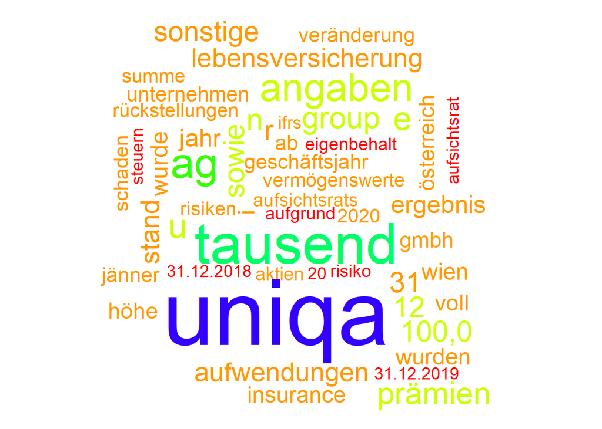

|  | Wort | Anzahl |
| --- | --- | --- |
| 1 | euro | 747 |
| 2 | uniqa | 594 |
| 3 | 2018 | 553 |
| 4 | 2019 | 530 |
| 5 | tausend | 347 |
| 6 | millionen | 265 |
| 7 | prozent | 263 |
| 8 | ag | 248 |
| 9 | angaben | 224 |
| 10 | u | 188 |

[output cut: 13353 more lines]

### Die Nachbarschaft von Risiko

Hier haben wir uns die 8 Worte um die Wörter risiken, risiko herum angeschaut:

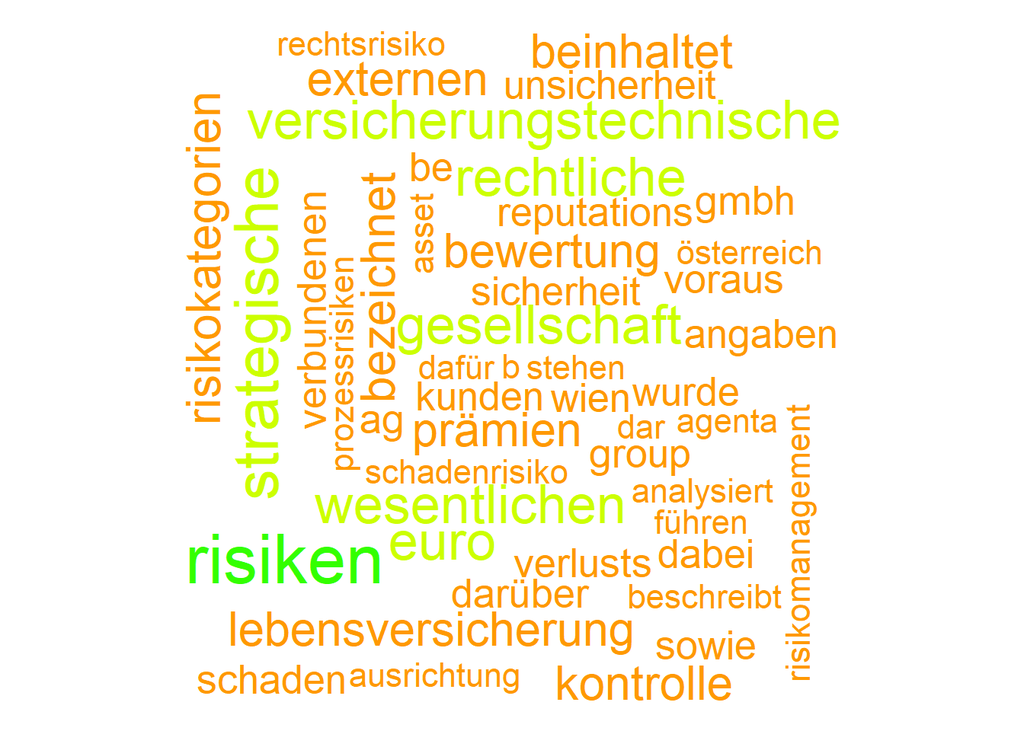

|  | Wort | Anzahl |
| --- | --- | --- |
| 1 | uniqa | 26 |
| 2 | risiko | 20 |
| 3 | identifikation | 11 |
| 4 | 2019 | 10 |
| 5 | operationelle | 10 |
| 6 | risiken | 8 |
| 7 | strategische | 7 |
| 8 | euro | 6 |
| 9 | gesellschaft | 6 |
| 10 | rechtliche | 6 |

[output cut: 808 more lines]

## Topic Modelling

Hier verwenden wir statistische Modelle (Latent Dirichlet Allocation) um aus großen Textmengen über Ähnlichkeitsmaße “Themen” zu finden.

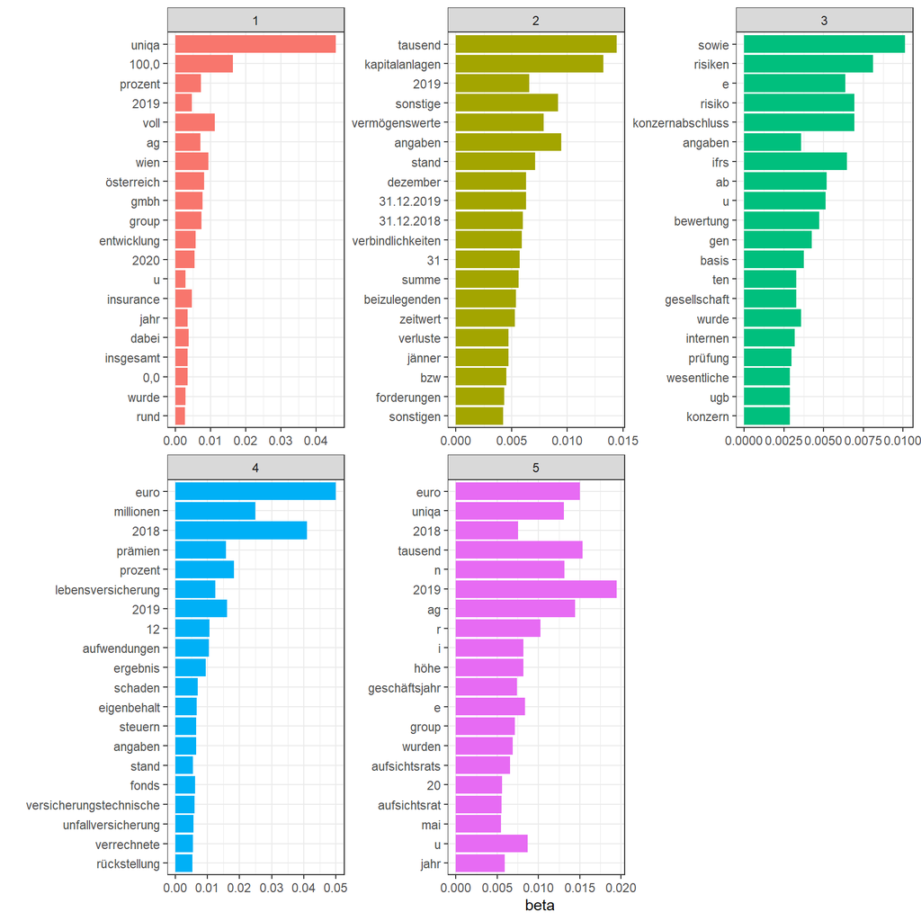

## Sentiment analysis

> “[…]bag of words methods usually categorize only 60 % of sentiments accurately”

> — „Artificial Intelligence: A Modern Approch“, Peter Norvig

Daher Achtung bei der Auswertung, das hier ist eine “bag of words”-Methode.

für die Sentiment Analyse wurde das Dictionary [germanlex](https://github.com/sebastiansauer/pradadata) verwendet. Es gab 963 übereinstimmende Wörter.

Im allgemeinen ist die Formulierung der gefundenen Wörter zu 0.6996055 positiv und zu 0.8107477 negativ behaftet - diese Zahlen beziehen sich auf die durchschnittliche “Stärke” der verwendeten Wörter. Es wurden 507 positive und 214 negative Worte gefunden.

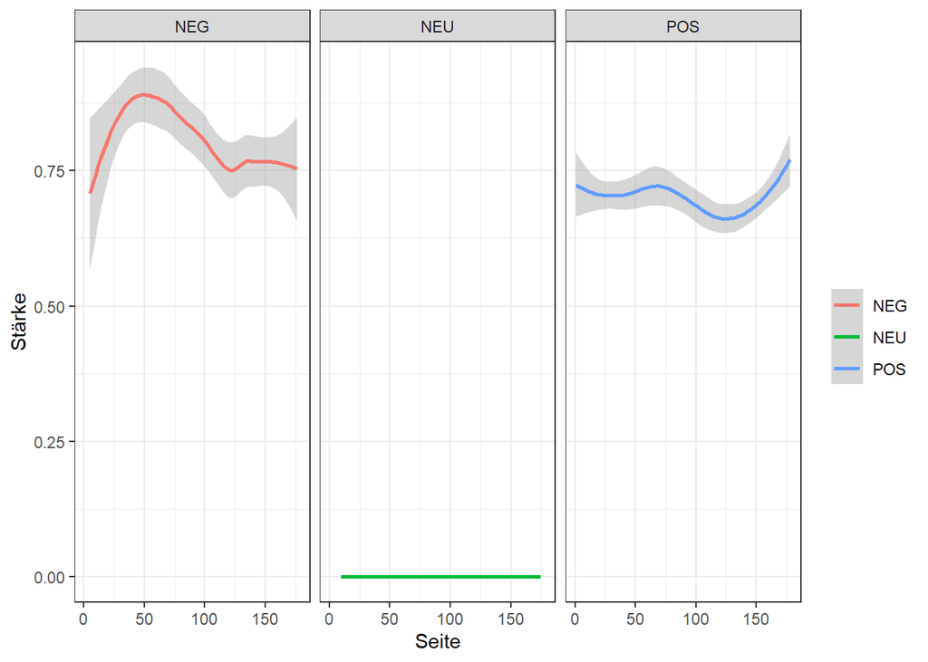